# Reproducible Research Course Project 2

yhuai 4/13/2018

## Synopsis

Storms and other severe weather events can cause both public health and economic problems for communities and municipalities. Many severe events can result in fatalities, injuries, and property damage, and preventing such outcomes to the extent possible is a key concern.

This project involves exploring the U.S. National Oceanic and Atmospheric Administration’s (NOAA) storm database. This database tracks characteristics of major storms and weather events in the United States, including when and where they occur, as well as estimates of any fatalities, injuries, and property damage.

The analysis result shows that “Tornado” is the most harmful to population health, and “Flood” has the greatest economic consequences.

## Read the data

```r
library(ggplot2)
library(dplyr)
fileURL <- "https://d396qusza40orc.cloudfront.net/repdata%2Fdata%2FStormData.csv.bz2"
download.file(fileURL,"Storm.csv.bz2")
data <- read.csv("Storm.csv.bz2")
```

## Data Processing

Summary

```r
dim(data)
```

```
## [1] 692288     37
```

```r
names(data)
```

```
##  [1] "STATE__"    "BGN_DATE"   "BGN_TIME"   "TIME_ZONE"  "COUNTY"
##  [6] "COUNTYNAME" "STATE"      "EVTYPE"     "BGN_RANGE"  "BGN_AZI"
## [11] "BGN_LOCATI" "END_DATE"   "END_TIME"   "COUNTY_END" "COUNTYENDN"
## [16] "END_RANGE"  "END_AZI"    "END_LOCATI" "LENGTH"     "WIDTH"
## [21] "F"          "MAG"        "FATALITIES" "INJURIES"   "PROPDMG"
## [26] "PROPDMGEXP" "CROPDMG"    "CROPDMGEXP" "WFO"        "STATEOFFIC"
## [31] "ZONENAMES"  "LATITUDE"   "LONGITUDE"  "LATITUDE_E" "LONGITUDE_"
## [36] "REMARKS"    "REFNUM"
```

### Get the variables related to our goal

1. evtype: weather event type
2. FATALITIES: number of deaths
3. INJURIES: number of injuries
4. PROPDMG/propdmgexp/CROPDMG/cropdmgexp: property damage

```r
sub_storm <- select(data, EVTYPE, FATALITIES:CROPDMGEXP)
```

First, we have to replacement the categories for the event types

Then, for the property damage we have to translate the values in propdmgexp and cropdmgexp: Hh = 100 Kk = 1,000 Mm = 1,000,000 Bb = 1,000,000,000 number = number others = 0

```r
replace_types <- c("TORNADO","WIND","HAIL","HEAT","FLOOD","RAIN","STORM","HURRICANE", "SNOW", "LIGHTNING", "ICE")
sub_storm$event_type <- "OTHER"
for (i in replace_types){
  sub_storm$event_type[grep(i, sub_storm$EVTYPE, ignore.case = TRUE)] <- i
}

sub_storm$PROPDMGEXP[is.na(sub_storm$PROPDMGEXP)] <- 0
sub_storm$PROPDMGEXP[(sub_storm$PROPDMGEXP =='')|(sub_storm$PROPDMGEXP =='+')|(sub_storm$PROPDMGEXP =='?')|(sub_storm$PROPDMGEXP =='-')|(sub_storm$PROPDMGEXP =='0')] <- 0
sub_storm$PROPDMGEXP[(sub_storm$PROPDMGEXP =='h')|(sub_storm$PROPDMGEXP =='H')] <- 2
sub_storm$PROPDMGEXP[(sub_storm$PROPDMGEXP =='k')|(sub_storm$PROPDMGEXP =='K')] <- 3
sub_storm$PROPDMGEXP[(sub_storm$PROPDMGEXP =='m')|(sub_storm$PROPDMGEXP =='M')] <- 6
sub_storm$PROPDMGEXP[(sub_storm$PROPDMGEXP =='b')|(sub_storm$PROPDMGEXP =='B')] <- 9
sub_storm$CROPDMGEXP[is.na(sub_storm$CROPDMGEXP)] <- 0
sub_storm$CROPDMGEXP[(sub_storm$CROPDMGEXP =='')|(sub_storm$CROPDMGEXP =='+')|(sub_storm$CROPDMGEXP =='?')|(sub_storm$CROPDMGEXP =='-')|(sub_storm$CROPDMGEXP =='0')] <- 0
sub_storm$CROPDMGEXP[(sub_storm$CROPDMGEXP =='h')|(sub_storm$CROPDMGEXP =='H')] <- 2
sub_storm$CROPDMGEXP[(sub_storm$CROPDMGEXP =='k')|(sub_storm$CROPDMGEXP =='K')] <- 3
sub_storm$CROPDMGEXP[(sub_storm$CROPDMGEXP =='m')|(sub_storm$CROPDMGEXP =='M')] <- 6
sub_storm$CROPDMGEXP[(sub_storm$CROPDMGEXP =='b')|(sub_storm$CROPDMGEXP =='B')] <- 9
sub_storm$PROPDMG <- as.numeric(as.character(sub_storm$PROPDMG))
sub_storm$PROPDMGEXP <- as.numeric(as.character(sub_storm$PROPDMGEXP))
sub_storm$propertydmg <- sub_storm$PROPDMG*(10^sub_storm$PROPDMGEXP)

sub_storm$CROPDMG <- as.numeric(as.character(sub_storm$CROPDMG))
sub_storm$CROPDMGEXP <- as.numeric(as.character(sub_storm$CROPDMGEXP))
sub_storm$cropdmg <- sub_storm$CROPDMG*(10^sub_storm$CROPDMGEXP)
```

### Sum the values into health_damage and economic_damage

```r
sub_storm$FATALITIES <- as.numeric(as.character(sub_storm$FATALITIES))
sub_storm$INJURIES <- as.numeric(as.character(sub_storm$INJURIES))
health <- aggregate(x=list(health_damage = sub_storm$FATALITIES + sub_storm$INJURIES), by=list(event_type=sub_storm$event_type), FUN=sum, na.rm=TRUE)
health <- health[order(health$health_damage, decreasing=TRUE),]


economic<- aggregate(x=list(economic_damage = sub_storm$propertydmg + sub_storm$cropdmg), by=list(event_type=sub_storm$event_type), FUN=sum, na.rm=TRUE)
economic<- economic[order(economic$economic_damage, decreasing=TRUE),]
```

### Get top 10 event type with highest health and economic damage

```r
order1 <- health[1:10,]
order2 <- economic[1:10,]
```

## Show the results in the plots

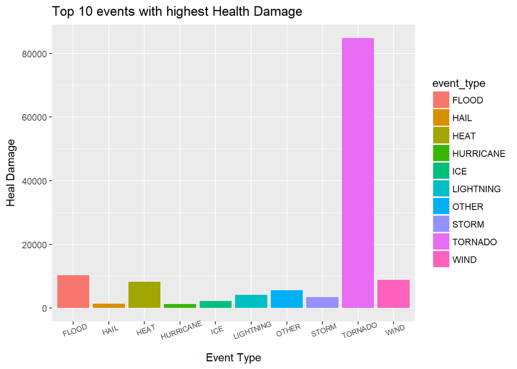

```r
g1 <- ggplot(order1, aes(x=event_type,y=health_damage,fill=event_type))
g1 <- g1 + geom_bar(stat = "identity")
g1 <- g1 + labs(x="Event Type", y="Heal Damage", title="Top 10 events with highest Health Damage")
g1 <- g1 +  theme(axis.text.x =  element_text(size = 7,  angle = 20))
g1
```

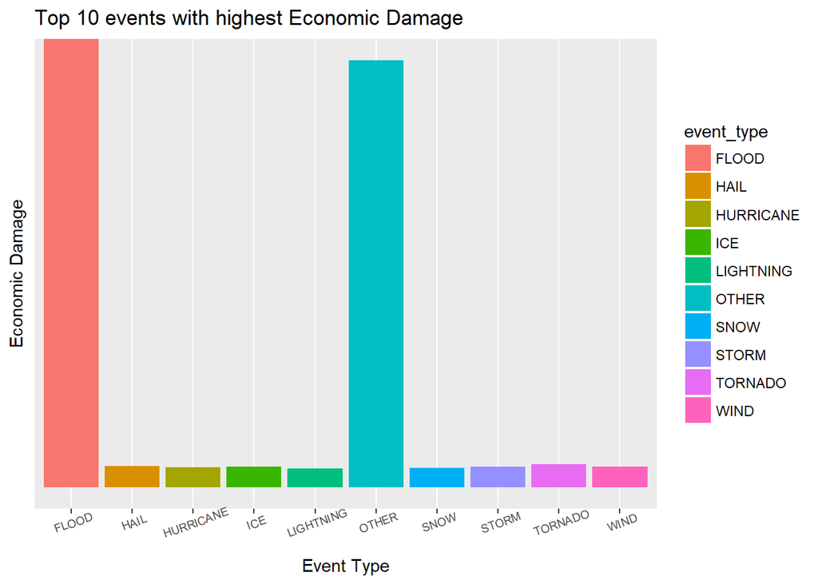

```r
g2 <- ggplot(order2, aes(x=event_type,y=log(economic_damage),fill=event_type))
g2 <- g2 + geom_bar(stat = "identity")
g2 <- g2 + labs(x="Event Type", y="Economic Damage", title="Top 10 events with highest Economic Damage")
g2 <- g2 + theme(axis.text.x =  element_text(size = 7,  angle = 20))
g2 <- g2 + scale_y_continuous(breaks = NULL)
g2
```